# Soc-Xsit Inspection Time Models

Plot model predictions to better understand the coefficients. We limit all models to include only two-way interactions. Here, I only interpret the coefficients related to inspection time since the results for the other coefficients do not change when inspection times are added to the models.

### Experiment 1

```r
m1_e1_inspect <- glmer(correct ~ (condition + trialType +
                                    log2(numPicN) +
                                    log2(intervalNum + 1) +
                                    log2(inspection_time_exposure_sec))^2 +
                         (trialType | subid),
                       offset = logit(1/numPicN),
                       control=glmerControl(optimizer="bobyqa"),
                       family=binomial,
                       nAGQ=0,
                       data=df_e1_filt)

broom::tidy(m1_e1_inspect) %>%
  filter(group == "fixed") %>%
  mutate_at(.cols = c("estimate", "std.error", "statistic", "p.value"),
            .funs = round, digits = 3) %>%
  mutate(p.value = ifelse(round(p.value, 3) == 0, "< .001", round(p.value, 3))) %>%
  knitr::kable()
```

| term | estimate | std.error | statistic | p.value | group |
| --- | --- | --- | --- | --- | --- |
| (Intercept) | 2.893 | 0.341 | 8.494 | < .001 | fixed |
| conditionSocial | 0.115 | 0.269 | 0.428 | 0.669 | fixed |
| trialTypeSwitch | -1.454 | 0.253 | -5.757 | < .001 | fixed |
| log2(numPicN) | 0.053 | 0.135 | 0.394 | 0.693 | fixed |
| log2(intervalNum + 1) | -0.471 | 0.113 | -4.154 | < .001 | fixed |
| log2(inspection_time_exposure_sec) | 0.204 | 0.148 | 1.376 | 0.169 | fixed |
| conditionSocial:trialTypeSwitch | -1.020 | 0.130 | -7.862 | < .001 | fixed |
| conditionSocial:log2(numPicN) | 0.359 | 0.098 | 3.675 | < .001 | fixed |
| conditionSocial:log2(intervalNum + 1) | 0.095 | 0.059 | 1.612 | 0.107 | fixed |
| conditionSocial:log2(inspection_time_exposure_sec) | -0.173 | 0.068 | -2.551 | 0.011 | fixed |
| trialTypeSwitch:log2(numPicN) | -0.619 | 0.093 | -6.669 | < .001 | fixed |
| trialTypeSwitch:log2(intervalNum + 1) | 0.519 | 0.055 | 9.386 | < .001 | fixed |
| trialTypeSwitch:log2(inspection_time_exposure_sec) | 0.094 | 0.069 | 1.358 | 0.174 | fixed |
| log2(numPicN):log2(intervalNum + 1) | -0.053 | 0.042 | -1.262 | 0.207 | fixed |
| log2(numPicN):log2(inspection_time_exposure_sec) | 0.049 | 0.052 | 0.945 | 0.345 | fixed |
| log2(intervalNum + 1):log2(inspection_time_exposure_sec) | 0.017 | 0.031 | 0.541 | 0.589 | fixed |

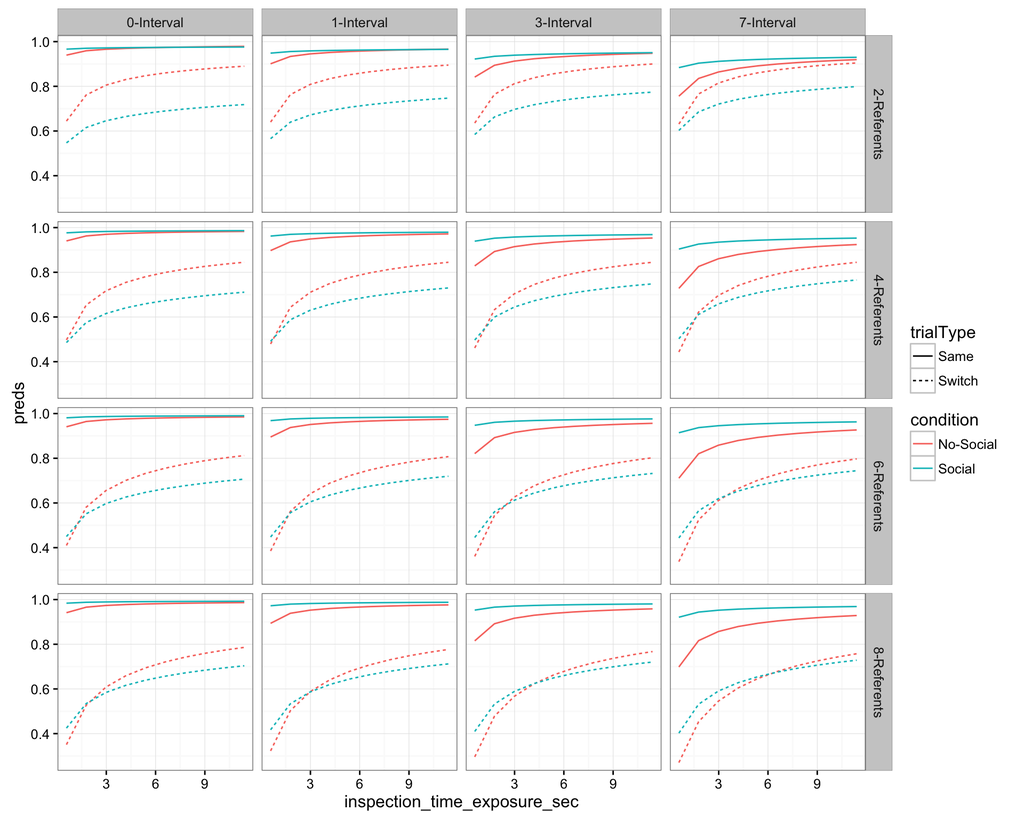

- No main effect of inspection time.
- Significant interaction between inspection time and gaze condition (longer inspection times provide bigger boost for no-gaze condition).
- No other significant interactions with inspection time

### Is there an effect of gaze on same trials in E1 ?

Pairwise comparison collapsing across interval and number of referents

```r
lsm_obj_e1 <- lsmeans(m1_e1_inspect, ~ condition | trialType)
e1_pairs <- pairs(lsm_obj_e1, adjust = "bon")
summary(e1_pairs) %>% knitr::kable(digits = 3)
```

| contrast | trialType | estimate | SE | df | z.ratio | p.value |
| --- | --- | --- | --- | --- | --- | --- |
| No-Social - Social | Same | -0.839 | 0.112 | NA | -7.521 | 0.000 |
| No-Social - Social | Switch | 0.180 | 0.087 | NA | 2.083 | 0.037 |

KM thoughts: There apprears to be more evidence for a boost to same trials with gaze than I thought. It looks like the boost is more likely to show up at higher intervals and at higher number of referents, but is also significant in just the pairwise comparison of same/switch trials across the gaze conditions. My best guess is that the higher interval and referent conditions taxed attention and memory more in the no-gaze condition (paticipants felt they had to spread attention across the referents), whereas in the gaze condition, participants’ focused more attention/ on their selection, which led to better performance.

### Experiment 2

```r
m2_inspect_e2 <- glmer(correct ~ (condition_trial +
                                    trialType +
                                    log2(intervalNum + 1) +
                                    log2(inspection_time_exposure_sec))^2 +
                         (trialType | subid),
                       nAGQ=0,
                       glmerControl(optimizer = "bobyqa"),
                       family=binomial,
                       data = filter(df_expt2_analysis, trial_category == "test"))

 broom::tidy(m2_inspect_e2) %>%
   filter(group == "fixed") %>%
  mutate_at(.cols = c("estimate", "std.error", "statistic", "p.value"),
            .funs = round, digits = 3) %>%
  mutate(estimate = round(estimate, 2),
         p.value = ifelse(round(p.value, 3) == 0, "< .001", round(p.value, 3))) %>%
   knitr::kable()
```

| term | estimate | std.error | statistic | p.value | group |
| --- | --- | --- | --- | --- | --- |
| (Intercept) | 2.41 | 0.289 | 8.338 | < .001 | fixed |
| condition_trialsocial | 0.13 | 0.230 | 0.585 | 0.559 | fixed |
| trialTypeSwitch | -3.12 | 0.256 | -12.214 | < .001 | fixed |
| log2(intervalNum + 1) | -0.88 | 0.138 | -6.342 | < .001 | fixed |
| log2(inspection_time_exposure_sec) | 0.15 | 0.134 | 1.138 | 0.255 | fixed |
| condition_trialsocial:trialTypeSwitch | -0.54 | 0.167 | -3.210 | 0.001 | fixed |
| condition_trialsocial:log2(intervalNum + 1) | 0.16 | 0.086 | 1.849 | 0.064 | fixed |
| condition_trialsocial:log2(inspection_time_exposure_sec) | -0.14 | 0.101 | -1.366 | 0.172 | fixed |
| trialTypeSwitch:log2(intervalNum + 1) | 0.77 | 0.096 | 8.000 | < .001 | fixed |
| trialTypeSwitch:log2(inspection_time_exposure_sec) | 0.21 | 0.107 | 1.961 | 0.05 | fixed |
| log2(intervalNum + 1):log2(inspection_time_exposure_sec) | 0.04 | 0.058 | 0.773 | 0.44 | fixed |

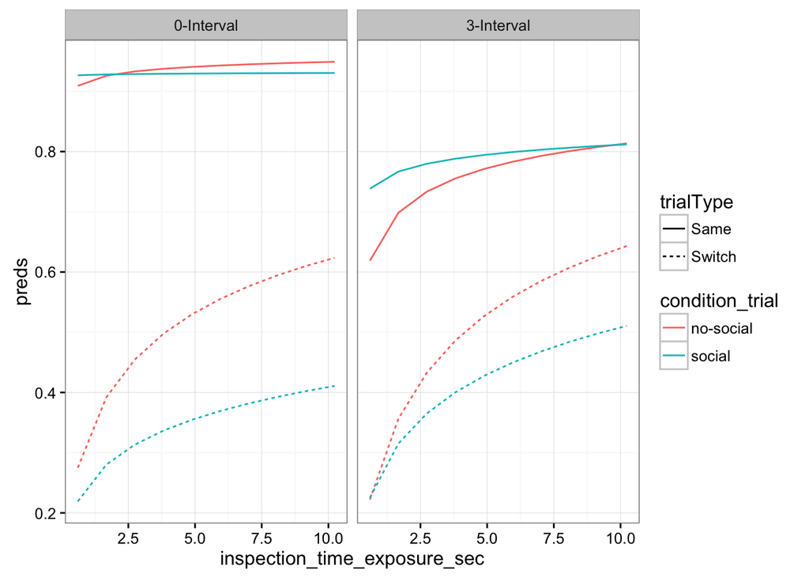

- No main effect of inspection time
- Significant interaction between trial type and inspection time (longer inspection provide bigger boost switch trials compared to same trials)

### Pairwise comparisons E2

```r
lsm_obj_e2 <- lsmeans(m2_inspect_e2, ~ condition_trial | trialType)
e2_pairs <- pairs(lsm_obj_e2, adjust = "bon")
summary(e2_pairs) %>% knitr::kable(digits = 3)
```

| contrast | trialType | estimate | SE | df | z.ratio | p.value |
| --- | --- | --- | --- | --- | --- | --- |
| no-social - social | Same | -0.124 | 0.139 | NA | -0.887 | 0.375 |
| no-social - social | Switch | 0.412 | 0.106 | NA | 3.874 | 0.000 |

No difference between same trials in the gaze vs. no-gaze condition. Perhaps because we did not test at high enough attention and memory demands.

### Experiment 3

```r
df_analysis_e3 <- df_expt3 %>%
  filter(trial_category == "exposure", block == "test",
         include_good_rt == "include") %>%
  select(subid, itemNum, inspection_time_exposure = rt) %>%
  mutate(inspection_time_exposure_sec = inspection_time_exposure / 1000) %>%
  left_join(filter(df_expt3, trial_category == "test", block == "test",
                   include_good_rt == "include"),
            by = c("subid", "itemNum"))
```

```r
# does inspection time affect test trial performance
m_inspect_e3 <- glmer(correct ~ (log2(inspection_time_exposure_sec) +
                                  trialType +
                                  reliability)^2 +
                     (trialType | subid),
                  control = glmerControl(optimizer = "bobyqa"),
                  nAGQ = 0,
                  family = binomial,
                  data = df_analysis_e3)

# get betas and p.vals
broom::tidy(m_inspect_e3) %>%
  filter(group == "fixed") %>%
   mutate_at(.cols = c("estimate", "std.error", "statistic", "p.value"),
            .funs = round, digits = 3) %>%
  mutate(estimate = round(estimate, 2),
         p.value = ifelse(round(p.value, 3) == 0, "< .001", round(p.value, 3))) %>%
knitr::kable()
```

| term | estimate | std.error | statistic | p.value | group |
| --- | --- | --- | --- | --- | --- |
| (Intercept) | 2.01 | 0.195 | 10.306 | < .001 | fixed |
| log2(inspection_time_exposure_sec) | 0.31 | 0.095 | 3.309 | 0.001 | fixed |
| trialTypeSwitch | -2.75 | 0.202 | -13.636 | < .001 | fixed |
| reliability | 0.50 | 0.303 | 1.658 | 0.097 | fixed |
| log2(inspection_time_exposure_sec):trialTypeSwitch | 0.03 | 0.089 | 0.337 | 0.736 | fixed |
| log2(inspection_time_exposure_sec):reliability | -0.20 | 0.110 | -1.835 | 0.067 | fixed |
| trialTypeSwitch:reliability | -0.58 | 0.294 | -1.974 | 0.048 | fixed |

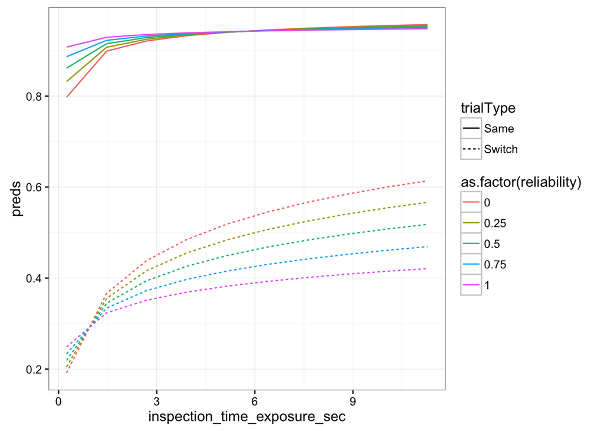

- Main effect of inspection time (longer is better).
- No interaction between inspection time and trial type.
- Weak interaction between inspection time and reliability (less of a boost for longer inspection times at higher levels of reliabilty).

### Things to address

- How to interpret the interaction between inspection time and gaze condition changing between E1 and E2. In E2 there is an interaction between inspection time and trial type. Note that if you remove interval in the E2 model, then you do see a sig interaction between gaze condition and inspection time like in E1, suggesting that interval is doing something to the link between inspection time and condition/trial-type.
- In E1, is there actually some evidence for a gaze boost to same trials at the higher number of referents and interval conditions? When I plotted the model predictions, it became more apparent that the models are capturing an advantage here.